# p8105_hw5_tw3128

Chris

2025-11-14

# 1 Problem One

## 1.1 fixed group size

```r
one_birthday_trial = function(n){
  birthdays = sample(1:365, size = n, replace = TRUE)
  repeated_bday <- length(unique(birthdays)) < n
  repeated_bday
}

one_birthday_trial(300)
```

```
## [1] TRUE
```

## 1.2 monte carlo simulation

```r
estimate_bdays_prob <- function(n, B = 10000) {
  if(!is.numeric(n)){
    stop("n must be numeric.")
  }
  mean(
    replicate(B, one_birthday_trial(n))
    )
}
```

```r
df_prob <-
  expand_grid(n = 2:50) |>
  rowwise() |>
  mutate(prob = estimate_bdays_prob(n)) |>
  ungroup()

df_prob
```

```
## # A tibble: 49 × 2
##        n   prob
##    <int>  <dbl>
##  1     2 0.0032
##  2     3 0.0086
##  3     4 0.0159
##  4     5 0.0279
##  5     6 0.0362
##  6     7 0.0583
##  7     8 0.0816
##  8     9 0.0968
##  9    10 0.117
## 10    11 0.136
## # ℹ 39 more rows
```

## 1.3 plotting

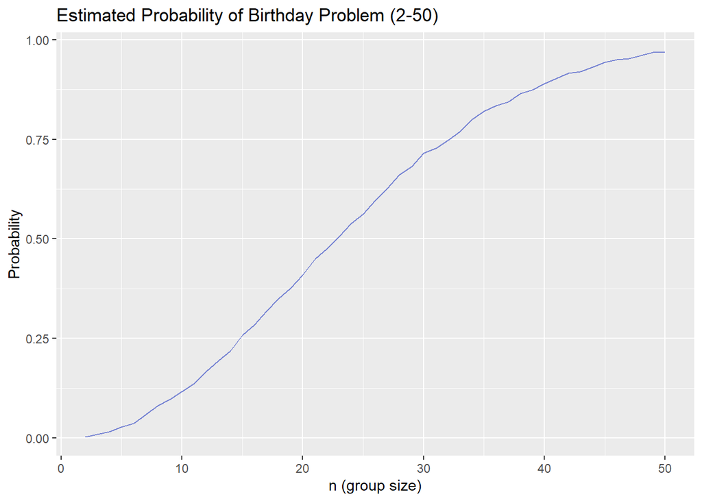

```r
df_prob |>
  ggplot(aes(x = n, y = prob)) +
  geom_line(alpha = 0.8, color = "#5a6acd") +
  labs(
    title = "Estimated Probability of Birthday Problem (2-50)",
    x = "n (group size)",
    y = "Probability"
  )
```

- Overall Trend
  - The probability of two people sharing the same birthday increased monotonically as n increases from 2 to 50.
  - Larger groups generate more possible pairs, which naturally raises the chance of a shared birthday.
- Birthday Paradox
  - When `n = 23`, the probability is already larger than `0.5`, which feels counterintuitive because 23 is far smaller than 365.
  - The reason is that the number of pairs is $\frac{n \times (n - 1)}{2}$, which can be larger than 365 even when n is small.

# 2 Problem Two

## 2.1 one sample t-test for $\mu = 0$

```r
simulate_tt = function(mu, n = 30, sigma = 5, B = 5000){
  replicate(
    B, {
      x <- rnorm(n = n, mean = mu, sd = sigma)
      tt <- t.test(x, mu = 0, )
      df_tt_tidy <- tidy(tt)
      df_estimations <-
        tibble(mu_hat = df_tt_tidy$estimate, p_value = df_tt_tidy$p.value)
    },
    simplify = FALSE) |>

    bind_rows() |>
    mutate(id = row_number()) |>
    relocate(id)
}

sim0 <- simulate_tt(0)
```

## 2.2 when $\mu$ equals other values

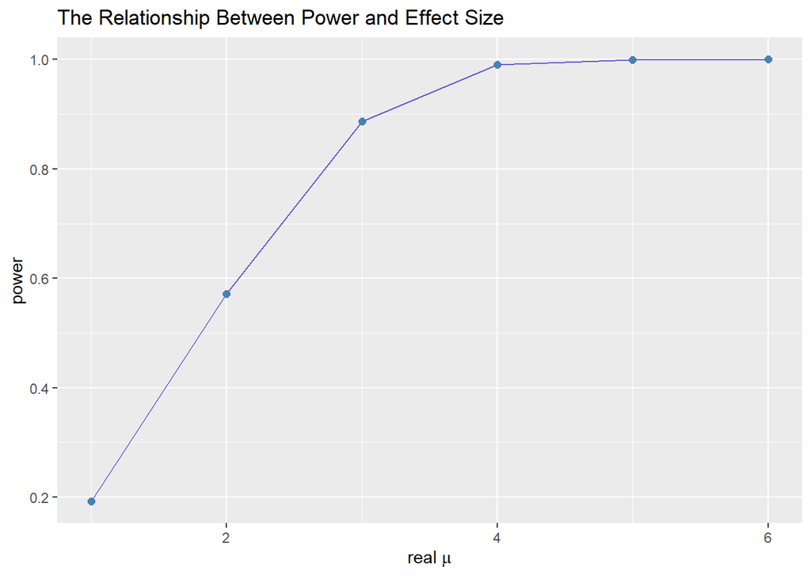

```r
mu_values <- 1:6

df_power <-
  map_dfr(
    mu_values,
    function(true_mu){
      sim <- simulate_tt(true_mu)
      power <- mean(sim$p_value < 0.05)

      tibble(
        true_mu ,
        power
      )
    }
  )

df_power |>
  ggplot(aes(x = true_mu, y = power)) +
  geom_line(color = "#6a5acd") + geom_point(size = 2, color = "steelblue") +
  labs(
    title = "The Relationship Between Power and Effect Size",
    x = expression("real " *  mu),
    y = "power"
  )
```

- Overall Trend
  - The powers of simple t tests increase monotonically when $\mu$ increases from 1 to 6.
- Segmented Conditions
  - When `$\mu$ = 1`, even though the null hypothesis is wrong, the power of testing is still low.
  - With the true mean increases, the power of testing increases sharply.

## 2.3 are the estimations unbiased or not

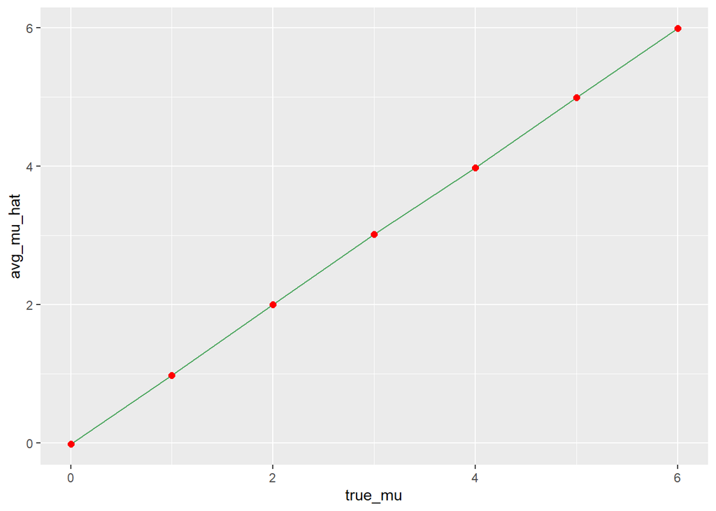

```r
mu_values <- 0:6

df_mu_hat <-

  map_dfr(
    mu_values,
    function(true_mu){
      sim <- simulate_tt(true_mu)
      avg_mu_hat <- mean(sim$mu_hat)
      avg_reject <- mean(sim$mu_hat[sim$p_value < 0.05], na.rm = TRUE)

      tibble(
        true_mu ,
        avg_mu_hat,
        avg_reject
      )
    }
  )

df_mu_hat |>
  ggplot(aes(x = true_mu, y = avg_mu_hat)) +
  geom_line(color = "#5a6") + geom_point(size = 2, color = "red")
```

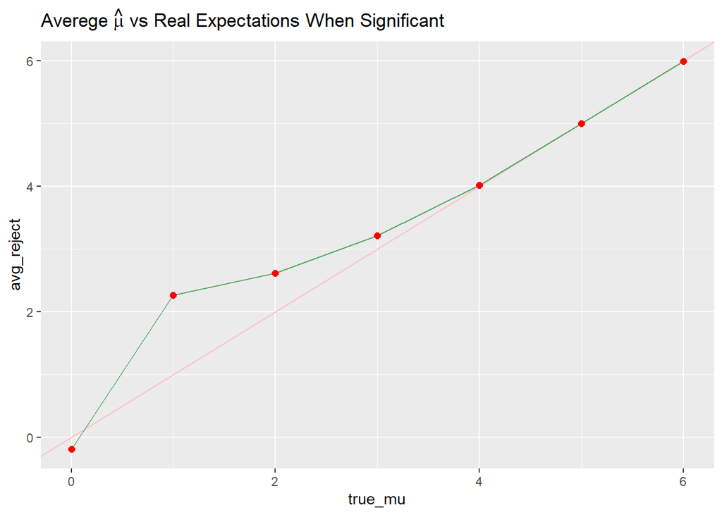

```r
df_mu_hat |>
  ggplot(aes(x = true_mu, y = avg_reject)) +
  geom_abline(intercept = 0, slope = 1, color = "pink") +
  geom_line(color = "#5a6") + geom_point(size = 2, color = "red") +
  labs(
    title = expression("Averege " * hat(mu) * " vs Real Expectations When Significant")
  )
```